# Project 2: Medical Appointment No Shows

### Why patients miss their scheduled appointments?

- Introduction
- Data Wrangling
- Exploratory Data Analysis
- Conclusions

## 1 Introduction

> This dataset collects information from 100k medical appointments in Brazil and is focused on the question of whether or not patients show up for their appointment. It has 13 associated variables (characteristics) about the patient and appointment made.

> **Questions:** A person makes the effort to schedule for a doctor appointment, but did not turn up on their scheduled appointment, why is it so? Below are the questions that I would like to find out from the dataset to understand the possible factors that increase the chances of not showing up in their scheduled appointment.
> - Is waiting time, the day of appointment, no sms reminder increase the chances of No-show?
> - Is there a particular groups of patient (age, gender, medical condition, handcap) more prompt to No-show?
> - Any health unit (neighborhood) having higher No-show rate?

> Understanding the reason could helps to reduce the *No-show rate* and thus, save operation cost for the government, as the services offered are free of charge.

> [Link to kaggle dataset](https://www.kaggle.com/joniarroba/noshowappointments)

```python
# Import libaries
import pandas as pd
import numpy as np
import datetime
from collections import Counter

# for plot
import matplotlib.pyplot as plt
import seaborn as sns
%matplotlib inline
```

## 2 Data Wrangling

> Data was loaded and inspected, check for data type, missing values, ambiguity data, and then trim, clean, engineer the dataset for analysis in the next section.

### 2.1 General Properties

```python
# Load data and view the first 5 rows of dataset
df = pd.read_csv('./data/noshowappointments-kagglev2-may-2016.csv')
df.head()
```

|  | PatientId | AppointmentID | Gender | ScheduledDay | AppointmentDay | Age | Neighbourhood | Scholarship | Hipertension | Diabetes | Alcoholism | Handcap | SMS_received | No-show |
| --- | --- | --- | --- | --- | --- | --- | --- | --- | --- | --- | --- | --- | --- | --- |
| 0 | 2.987250e+13 | 5642903 | F | 2016-04-29T18:38:08Z | 2016-04-29T00:00:00Z | 62 | JARDIM DA PENHA | 0 | 1 | 0 | 0 | 0 | 0 | No |
| 1 | 5.589978e+14 | 5642503 | M | 2016-04-29T16:08:27Z | 2016-04-29T00:00:00Z | 56 | JARDIM DA PENHA | 0 | 0 | 0 | 0 | 0 | 0 | No |
| 2 | 4.262962e+12 | 5642549 | F | 2016-04-29T16:19:04Z | 2016-04-29T00:00:00Z | 62 | MATA DA PRAIA | 0 | 0 | 0 | 0 | 0 | 0 | No |
| 3 | 8.679512e+11 | 5642828 | F | 2016-04-29T17:29:31Z | 2016-04-29T00:00:00Z | 8 | PONTAL DE CAMBURI | 0 | 0 | 0 | 0 | 0 | 0 | No |
| 4 | 8.841186e+12 | 5642494 | F | 2016-04-29T16:07:23Z | 2016-04-29T00:00:00Z | 56 | JARDIM DA PENHA | 0 | 1 | 1 | 0 | 0 | 0 | No |

### Data dictionary

| **No** | **Colume's name** | **Descriptions** |
| --- | --- | --- |
| 01 | PatientId | Identification of a patient |
| 02 | AppointmentID | Identification of each appointment |
| 03 | Gender | Male or Female |
| 04 | ScheduledDay | The day someone called or registered the appointment, this is before appointment. |
| 05 | AppointmentDay | The day of the actuall appointment, when they have to visit the doctor. |
| 06 | Neighbourhood | Neighbourhood where health unites are located within the city of Vitória. |
| 07 | Scholarship | Yes/ No. Indicates whether or not the patient is enrolled in Brasilian welfare program [Bolsa Família](https://en.wikipedia.org/wiki/Bolsa_Fam%C3%ADlia) |
| 08 | Hipertension,Diabetes,Alcoholism | True or false |
| 09 | Handcap | Number of desabilites a person has |
| 10 | SMS_received | 1 or more messages sent to the patient. |
| 11 | No-show | Yes/ No. **No** if the patient **showed up to their appointment** |

### Summary of dataset

- There are total of 14 columns, 13 indipendent variable and 1 dependent variable (`No-show`).
- Total 110527 rows with no missing values
- `ScheduledDay` and `AppointmentDay` are date in string datatype, to be changed to *datetime* datatype.
- `PatientId` is in numeric format (float64) which does not carries any numeric meaning. To be changed to *string* datatype instead.

```python
df.info()
```

```
<class 'pandas.core.frame.DataFrame'>
RangeIndex: 110527 entries, 0 to 110526
Data columns (total 14 columns):
 #   Column          Non-Null Count   Dtype
---  ------          --------------   -----
 0   PatientId       110527 non-null  float64
 1   AppointmentID   110527 non-null  int64
 2   Gender          110527 non-null  object
 3   ScheduledDay    110527 non-null  object
 4   AppointmentDay  110527 non-null  object
 5   Age             110527 non-null  int64
 6   Neighbourhood   110527 non-null  object
 7   Scholarship     110527 non-null  int64
 8   Hipertension    110527 non-null  int64
 9   Diabetes        110527 non-null  int64
 10  Alcoholism      110527 non-null  int64
 11  Handcap         110527 non-null  int64
 12  SMS_received    110527 non-null  int64
 13  No-show         110527 non-null  object
dtypes: float64(1), int64(8), object(5)
memory usage: 11.8+ MB
```

### 2.2 Data manupulation

Change the data types, add column with engineered data

```python
# change the `ScheduledDay` and `AppointmentDay` datatype to datetime datatype using
# np.datetime64 format

df['ScheduledDay'] = df.ScheduledDay.apply(np.datetime64)
df['AppointmentDay'] = df.AppointmentDay.apply(np.datetime64)
```

```python
# get the day of the week from both `ScheduledDay` and `AppointmentDay`,
# using .isoweekday(), where Monday = 1, Sunday = 7

df['Scheduled_weekday'] = df.ScheduledDay.dt.date.apply(lambda x:x.isoweekday())
df['Appointment_weekday'] = df.AppointmentDay.dt.date.apply(lambda x:x.isoweekday())

# find how many days appointment is made in advance of the scheduled day (waiting time)
df['days_toAppointment'] = (df.AppointmentDay - df.ScheduledDay).dt.days
```

```python
# create another column to list the day of scheduled & appointment in str
weekday_name = ['start_form_1','Mon','Tue','Wed','Thur','Fri','Sat','Sun']
df['ScheduledDay_str'] = [weekday_name[x] for x in df.Scheduled_weekday]
df['AppointmentDay_str'] = [weekday_name[x] for x in df.Appointment_weekday]
```

```python
# Change the patient id's datatype from float to string, for patient ID analysis
df['PatientId'] = df['PatientId'].apply(lambda x: str(x).split('.')[0])
```

```python
# replace category variable of 'No-show' to binary
# No-show : No -> 0
# No-show : Yes -> 1
df['No-show'] = df['No-show'].map({'No': 0, 'Yes':1})
```

```python
# drop AppointmentID as this is just a record with no additional information provided
# in my analysis
df.drop('AppointmentID', axis=1, inplace = True)
```

### 2.3 Statistical summary

### 2.3.1 Numeric column

- Majority of patient is without `Hipertension`, `Diabetes`, `Alcoholism`.
- Majority of patient is without disabilities, `Handcap`.
- Majority of patient is NOT enrolled in Brasilian welfare program.
- `No-show`, 20.2% (i.e. the mean in statistics) patient No-show in their scheduled appointment.
- No scheduling/appointment is made on Sunday.

Ambiguity or suspicious data, that need to be checked and cleaned in the *cleaning section*

- `Age` : min age is **-1**.
- `days_toAppointment` : min is **-7** and with 25% percentile of **-1**, which indicates the appointment made **after** scheduled appointment.

```python
df.describe()
```

|  | Age | Scholarship | Hipertension | Diabetes | Alcoholism | Handcap | SMS_received | No-show | Scheduled_weekday | Appointment_weekday | days_toAppointment |
| --- | --- | --- | --- | --- | --- | --- | --- | --- | --- | --- | --- |
| count | 110527.000000 | 110527.000000 | 110527.000000 | 110527.000000 | 110527.000000 | 110527.000000 | 110527.000000 | 110527.000000 | 110527.000000 | 110527.000000 | 110527.000000 |
| mean | 37.088874 | 0.098266 | 0.197246 | 0.071865 | 0.030400 | 0.022248 | 0.321026 | 0.201933 | 2.851955 | 2.858243 | 9.183702 |
| std | 23.110205 | 0.297675 | 0.397921 | 0.258265 | 0.171686 | 0.161543 | 0.466873 | 0.401444 | 1.378520 | 1.371672 | 15.254996 |
| min | -1.000000 | 0.000000 | 0.000000 | 0.000000 | 0.000000 | 0.000000 | 0.000000 | 0.000000 | 1.000000 | 1.000000 | -7.000000 |
| 25% | 18.000000 | 0.000000 | 0.000000 | 0.000000 | 0.000000 | 0.000000 | 0.000000 | 0.000000 | 2.000000 | 2.000000 | -1.000000 |
| 50% | 37.000000 | 0.000000 | 0.000000 | 0.000000 | 0.000000 | 0.000000 | 0.000000 | 0.000000 | 3.000000 | 3.000000 | 3.000000 |
| 75% | 55.000000 | 0.000000 | 0.000000 | 0.000000 | 0.000000 | 0.000000 | 1.000000 | 0.000000 | 4.000000 | 4.000000 | 14.000000 |
| max | 115.000000 | 1.000000 | 1.000000 | 1.000000 | 1.000000 | 4.000000 | 1.000000 | 1.000000 | 6.000000 | 6.000000 | 178.000000 |

### 2.3.2 datetime column

- `AppointmentDay` : Between April and June 2016
- `ScheduledDay` : Between Nov 15 and June 2016. The time's precision is up to seconds (e.g. 2016-05-06 07:09:54) whereas `AppointmentDay` precision is only at date (e.g. 2016-06-06 00:00:00), the %H%M%s are all zeros.

```python
df[['ScheduledDay','AppointmentDay']].describe()
```

|  | ScheduledDay | AppointmentDay |
| --- | --- | --- |
| count | 110527 | 110527 |
| unique | 103549 | 27 |
| top | 2016-05-06 07:09:54 | 2016-06-06 00:00:00 |
| freq | 24 | 4692 |
| first | 2015-11-10 07:13:56 | 2016-04-29 00:00:00 |
| last | 2016-06-08 20:07:23 | 2016-06-08 00:00:00 |

### 2.3.3 string column

- `PatientId` : Only 62299 unique patient from the 110527 appointment made. This means there are multiple appointments made by same patient. Asides, 1 patient made up to 88 appointment wihtin the schedulig time span of *7 months* (Nov 15 and June 2016).
- `Gender` : Majority appointment is made by **female** patient at 71840 counts.
- `Neighbourhood` : Total of **81 unique neighborhood** with *JARDIM CAMBURI* the most common value at 7717 counts.

```python
df.describe(include = [np.object])
```

|  | PatientId | Gender | Neighbourhood | ScheduledDay_str | AppointmentDay_str |
| --- | --- | --- | --- | --- | --- |
| count | 110527 | 110527 | 110527 | 110527 | 110527 |
| unique | 62299 | 2 | 81 | 6 | 6 |
| top | 822145925426128 | F | JARDIM CAMBURI | Tue | Wed |
| freq | 88 | 71840 | 7717 | 26168 | 25867 |

### 2.4 Data Cleaning

#### 2.4.1 `Age`

- There is only **one** patient at age **-1**. The data shows that the patient turn up for the appointment. Suspected to be due to typo error. Since I am is still not known the actual age of the patient, as he/she not repeated patient. Thus, decided to drop this row, since it is only 1 row and came from majority group of `no-show`=0 (i.e. No)

```python
# find how many patient is at age = -1
df.Age.value_counts()
```

```
 0      3539
 1      2273
 52     1746
 49     1652
 53     1651
        ...
 115       5
 100       4
 102       2
 99        1
-1         1
Name: Age, Length: 104, dtype: int64
```

```python
patient_id = df[df['Age']==-1]['PatientId'].iloc[0]
# find all rows with patientId with age= -1
df[df['PatientId']== patient_id]
```

|  | PatientId | Gender | ScheduledDay | AppointmentDay | Age | Neighbourhood | Scholarship | Hipertension | Diabetes | Alcoholism | Handcap | SMS_received | No-show | Scheduled_weekday | Appointment_weekday | days_toAppointment | ScheduledDay_str | AppointmentDay_str |
| --- | --- | --- | --- | --- | --- | --- | --- | --- | --- | --- | --- | --- | --- | --- | --- | --- | --- | --- |
| 99832 | 465943158731293 | F | 2016-06-06 08:58:13 | 2016-06-06 | -1 | ROMÃO | 0 | 0 | 0 | 0 | 0 | 0 | 0 | 1 | 1 | -1 | Mon | Mon |

```python
# drop row with age = -1
df.drop(df.index[99832], inplace = True)
```

#### 2.4.2 `days_toAppointment`

- Negative value in this column means the scheduling is made after the appointment, which is **NOT logical**.
- **34.89%** data is with *-1*. It was found out that, the `ScheduledDay` and `AppointmentDay` are in the **same** day, but due to there is no time info in the `AppointmentDay`, which cause it to set it to 00:00:00 time when I find the timedelta between the 2 dates, resulted in -1 days. To change the -1 to 0 instead.
- **-2, -7** value is could be due to human error. But since there is only 5 of them, and I won't be able to find out the correct `ScheduledDay` or `AppointmentDay` for this, thus, to drop these 5 rows instead.

```python
# Find out the unique negative value for 'days_toAppointment'
# There are -1, -2, & -7 days to appointment
df.days_toAppointment.unique()[df.days_toAppointment.unique()<0]
```

```
array([-1, -2, -7])
```

```python
print("Percentage of days_toAppointment is -1: {}%".format(round(df.days_toAppointment.value_counts()[-1]/df.shape[0]*100,2)))
print("Counts of days_toAppointment at -2: {} and -7: {}".format(df.days_toAppointment.value_counts()[-2],
                                                            df.days_toAppointment.value_counts()[-7]))
df.days_toAppointment.value_counts()
```

```
Percentage of days_toAppointment is -1: 34.89%
Counts of days_toAppointment at -2: 4 and -7: 1
```

```
-1      38562
 1       6725
 3       5290
 0       5213
 6       4906
        ...
 150        1
 116        1
 126        1
 145        1
 81         1
Name: days_toAppointment, Length: 131, dtype: int64
```

```python
# For days_toAppointment = -1
# This is due to the Appointment day is only in date, no time (Hour, Minute, seconds) information, but
# ScheduledDay has the info for both date & time. Thus, it resulted to be all in time(00:00:00) for AppointmentDay
# Since both ScheduledDay & AppointmentDay on the same day, to change days_toAppointment to 0

df[df['days_toAppointment'] == -1][['ScheduledDay', 'AppointmentDay', 'days_toAppointment']]
```

|  | ScheduledDay | AppointmentDay | days_toAppointment |
| --- | --- | --- | --- |
| 0 | 2016-04-29 18:38:08 | 2016-04-29 | -1 |
| 1 | 2016-04-29 16:08:27 | 2016-04-29 | -1 |
| 2 | 2016-04-29 16:19:04 | 2016-04-29 | -1 |
| 3 | 2016-04-29 17:29:31 | 2016-04-29 | -1 |
| 4 | 2016-04-29 16:07:23 | 2016-04-29 | -1 |
| ... | ... | ... | ... |
| 110511 | 2016-06-08 08:50:20 | 2016-06-08 | -1 |
| 110512 | 2016-06-08 08:20:01 | 2016-06-08 | -1 |
| 110513 | 2016-06-08 07:52:55 | 2016-06-08 | -1 |
| 110514 | 2016-06-08 08:35:31 | 2016-06-08 | -1 |
| 110517 | 2016-06-07 07:38:34 | 2016-06-07 | -1 |

38562 rows × 3 columns

```python
# days_toAppointment = -2, -7
# This is clearly not possible for schedulling date after few days of the actual appointment date.
# Could be due to human error, where I will not know the actual date of ScheduledDay
# Since they are only 5 of them, will drop these 5 rows instead

df[df['days_toAppointment'] <-1][['ScheduledDay', 'AppointmentDay', 'days_toAppointment']]
```

|  | ScheduledDay | AppointmentDay | days_toAppointment |
| --- | --- | --- | --- |
| 27033 | 2016-05-10 10:51:53 | 2016-05-09 | -2 |
| 55226 | 2016-05-18 14:50:41 | 2016-05-17 | -2 |
| 64175 | 2016-05-05 13:43:58 | 2016-05-04 | -2 |
| 71533 | 2016-05-11 13:49:20 | 2016-05-05 | -7 |
| 72362 | 2016-05-04 06:50:57 | 2016-05-03 | -2 |

```python
# Change value of -1 to 0
df['days_toAppointment'] = df['days_toAppointment'].replace(-1,0)

# drop rows with value of -2 & -7
# get the index of rows to drop
i = df[df['days_toAppointment'] <-1].index.values
df.drop(i, inplace = True)
```

```python
# take a look on the statistic of days_toAppointment, 50% of them is <= 3 days
df.days_toAppointment.describe()
```

```
count    110521.000000
mean          9.533256
std          15.027972
min           0.000000
25%           0.000000
50%           3.000000
75%          14.000000
max         178.000000
Name: days_toAppointment, dtype: float64
```

```python
# Export cleaned data to csv
df.to_csv('./data/clean.csv', index = False)
```

## 3 Exploratory Data Analysis

### 3.1 Dependent variable, `No-show`

- **20.2%** (22314 out of 110521) No-show on their scheduled appointment.

```python
print("No-show counts:")
print(df['No-show'].value_counts())
print()
print("No-show in percentage:")
df['No-show'].value_counts(normalize = True)*100
```

```
No-show counts:
0    88207
1    22314
Name: No-show, dtype: int64

No-show in percentage:
```

```
0    79.810172
1    20.189828
Name: No-show, dtype: float64
```

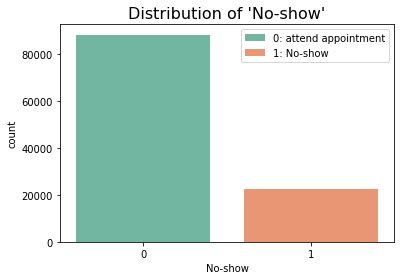

```python
# Visualise No-show via bar plot
plt.subplots(figsize=(6,4))
ax = sns.countplot(x="No-show", data=df, palette="Set2")

ax.legend(ax.patches, ["0: attend appointment", "1: No-show"])
ax.set_title("Distribution of 'No-show'", fontsize=16);
```

### 3.2 Is waiting time, the day of appointment, no sms reminder increase the chances of No-show?

```python
# Function for countplot
def count_pct_plot(df, x, hue_col, hue_title, title, pct_data):
    plt.subplots(figsize=(10,6))
    ax = sns.countplot(x = x, hue = hue_col, data = df, palette = "Set2")

    #print the percentage of no-show on each bar
    for p in ax.patches:
        x = p.get_bbox().get_points()[:,0]
        y = p.get_bbox().get_points()[1,1]
        ax.annotate('{:.2f}%'.format(100.*y/df.shape[0]), (x.mean(),y), ha= 'center', va = 'bottom')

    ax.legend(loc = 3).set_title(hue_title)
    ax.set_ylabel("Number of occurences", fontsize=12)

    ax2 = ax.twinx()
    ax2.plot(pct_data[:-1], color = "darkblue", marker = 'x', label = "No-show % ")
    ax2.set_ylim(0, pct_data.max()+10)
    ax2.legend(loc=1, frameon = False)
    ax2.set_ylabel("No-show percentage, %\n(# of No-show/total within same group)", fontsize=12)

    ax.set_title(title, fontsize=14)
```

```python
# Function to get the percentage data
def get_pct(df,x):

    temp = pd.crosstab(df['No-show'], df[x], margins = True, margins_name = 'Total')
    pct_per_x = temp.loc[1]/temp.loc["Total"]*100

    print("Percentage groupby {}".format(x))
    print(df[x].value_counts(normalize=True)*100)
    print()
    print("No-show percentage groupby:")
    print(pct_per_x)
    return pct_per_x
```

```python
# Function to plot heatmap
def plot_heatmap(data, figsize, title):
    mask = np.zeros_like(data)
    mask[np.triu_indices_from(mask)] = True

    with sns.axes_style("white"):
        f,ax = plt.subplots(figsize=figsize)
        ax = sns.heatmap(data, mask=mask, vmax=1, vmin=-1, annot=True,
                    linewidths = .5, cmap = "YlGnBu")
        ax.set_title(title, fontsize=14)
```

#### 3.2.1 days_toAppointment

Split the days to appointment (waiting time) into 6 groups:

- same day: 0
- week: 1-7
- forthnight: 8-15
- month: 16-30
- quarter: 31-90
- more than 90 days: 91- 178

**39.6%** appointment is within the same day and is make up to the majority group.  
The percentage of `No-show` increases with longer waiting time group, with **6.6%** for appointment within the **same day** and hike to **33.1%** for waiting time in `31-90 days`.

```python
# split waiting time into 6 groups mentioned above
bin_edges = [-0.01, 0, 7, 15, 30, 90, 178]  # left include = False
bin_names = ["same day", "1-7", "8-15", "16-30", "31-90", "91-178"]
df["waitingtime_group"] = pd.cut(df.days_toAppointment, bin_edges, labels = bin_names)
```

```python
# get the percentage data
pct_waitingtime = get_pct(df,"waitingtime_group")
```

```
Percentage groupby waitingtime_group
same day    39.607857
1-7         26.514418
16-30       13.924051
8-15        11.171633
31-90        8.636368
91-178       0.145674
Name: waitingtime_group, dtype: float64

No-show percentage groupby:
waitingtime_group
same day     6.636208
1-7         25.010238
8-15        31.157366
16-30       32.672688
31-90       33.116815
91-178      27.329193
Total       20.189828
dtype: float64
```

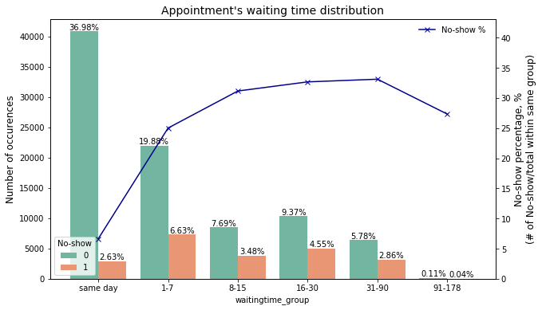

```python
# Visualise through plot
count_pct_plot(df, "waitingtime_group", "No-show", "No-show",
               "Appointment's waiting time distribution", pct_waitingtime)
```

I am interestd to find out the `No-show` repeated patient distribution. Thus, I created another dataframe that count for patient's occurence in each `waitingtime_group` in below code cell. Visualisation plot shows that:

- Number of appointment made per `No-show` patient is < 20. Relatively **less** frequent's patient for those attended their scheduled appointment.
- Frequent patient (>=20 appointment per patient) schedule appointment on the **same** day.
- Based on the plot, **more** `No-show` percentage for longer waiting time (more orange dots).

```python
# create another dataframe to count the number of appointment made by each patient
waitingtime_group = df.groupby(['waitingtime_group','PatientId', 'No-show']).size().reset_index(name = 'count')
```

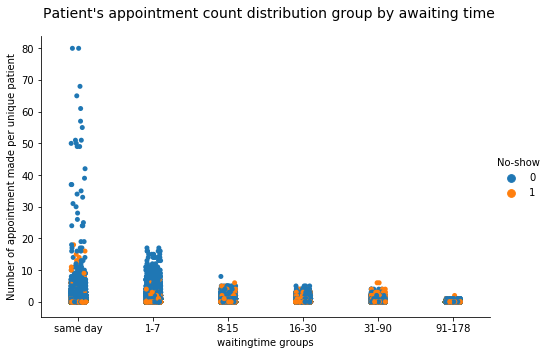

```python
# Visualise the data via category plot
ax = sns.catplot(x="waitingtime_group", y ="count", data = waitingtime_group,
                 hue ="No-show", height=5, aspect=1.4)

ax.set_axis_labels("waitingtime groups", "Number of appointment made per unique patient")
ax.fig.subplots_adjust(top=.9)
ax.fig.suptitle("Patient's appointment count distribution group by awaiting time", fontsize=14);
```

#### 3.2.2 Appointment_weekday

- More appointment scheduled on **Tuesday and Wednesday** (~ 23% each).
- Appointment on **Saturday** is the least, but has the highest `No-show` percentage, **23.1%**

```python
pct = get_pct(df,"Appointment_weekday")
```

```
Percentage groupby Appointment_weekday
3    23.403697
2    23.197401
1    20.550846
5    17.208494
4    15.604274
6     0.035287
Name: Appointment_weekday, dtype: float64

No-show percentage groupby:
Appointment_weekday
1        20.644565
2        20.087370
3        19.686074
4        19.349414
5        21.226142
6        23.076923
Total    20.189828
dtype: float64
```

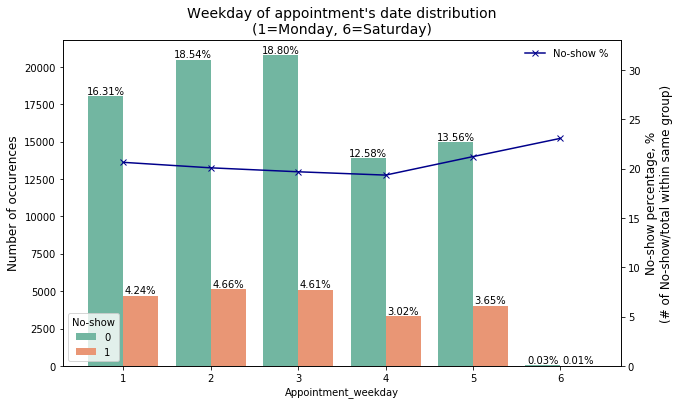

```python
#reset the pct index to zeroes before plotting the graph (to align with the x-axis)
pct.reset_index(drop=True, inplace = True)

count_pct_plot(df, "Appointment_weekday", "No-show", "No-show",
               "Weekday of appointment's date distribution\n(1=Monday, 6=Saturday)", pct)
```

#### 3.2.3 SMS_received

- Only **32.1%** of patient received sms notification.
- However, those received sms notification is haivng higher `No-show` percentage (**27.6%**)
- No SMS notification sent out for appointment on the **same day** of scheduling.
- For waitingdays group in **1-7 days**, lesser patient received SMS notification.
- For waiting days > a week, more patient received SMS notification. From section 3.2.1, longer waiting days has higher No-show percentage. Thus, this means, even with sms notification, possibility of **No-show** is still higher.

```python
pct = get_pct(df,"SMS_received")
```

```
Percentage groupby SMS_received
0    67.895694
1    32.104306
Name: SMS_received, dtype: float64

No-show percentage groupby:
SMS_received
0        16.697984
1        27.574545
Total    20.189828
dtype: float64
```

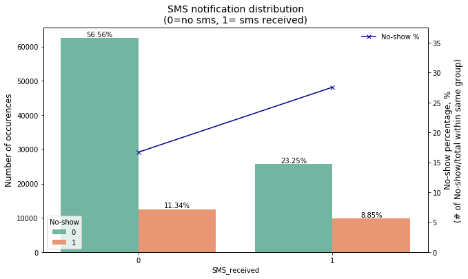

```python
#reset the pct index to zeroes before plotting the graph (to align with the x-axis)
pct.reset_index(drop=True, inplace = True)

count_pct_plot(df, "SMS_received", "No-show", "No-show",
               "SMS notification distribution\n(0=no sms, 1= sms received)", pct)
```

#### 3.2.4 Correlation among patient's appointment and `No-show`

I calculate the correlation matrix (using `.corr()`) among the `days_toAppointment`, `Appointment_weekday`, `SMS_received` and dependent variable of `No-show`.

Positive correlation observed between `days_toAppointment` and `SMS_received` in heatmap plotted below.

I also plot the `waitingtime_group` distribution again, but the bar split by `SMS_received`. The line chart within the same plot remain the `No-show` percentage for each `waitingtime_group`

Visualisation observed that:

- No sms notification for appointment made on the **SAME** day
- **Lesser** patient received sms notification for patient appointment waiting time in group **1-7 days**.
- **More** patient received sms notification for waiting time longer than a week. But, their `No-show` percentage is still higher.

```python
# column to count the correlation coefficient:
cols = ["days_toAppointment", "Appointment_weekday", "SMS_received", "No-show"]

# get the correlation coefficient:
corr = df[cols].corr()
```

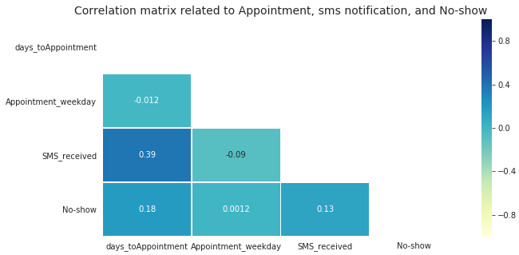

```python
# Plot the correlation coefficient using heatmap
plot_heatmap(corr, (10,5), "Correlation matrix related to Appointment, sms notification, and No-show")
```

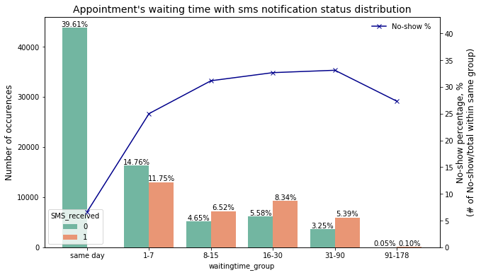

```python
count_pct_plot(df, "waitingtime_group", "SMS_received", "SMS_received",
               "Appointment's waiting time with sms notification status distribution", pct_waitingtime)
```

### 3.3 Is there a particular groups of patient (age, gender, diseases, handcap) more prompt to No-show?

#### 3.3.1 Age

- infant: 0-2
- preschooler: 3-6
- schooling: 7-18
- teenage: 19-24
- young_adult: 25-39
- middle_age: 40-64
- senior: 65-115

Majority group of pateint is from **Middle age group** (40-64), 33.3%.  
Patient with highest `No-show` percentage came form **teeange group** (19-24), 25.2%, but this group of patient is only about 7.6% of the total patient population.

```python
# split age into 7 groups according to above code cell
bin_edges = [-0.01,2, 6, 18, 24, 39, 64, 115]
bin_names = ["0-2", "3-6", "7-18", "19-24", "25-39", "40-64", "65-115"]
df['age_group'] = pd.cut(df.Age, bin_edges, labels = bin_names)
```

```python
pct_age = get_pct(df,"age_group")
```

```
Percentage groupby age_group
40-64     33.335746
25-39     19.917482
7-18      14.126727
65-115    13.030103
19-24      7.599461
0-2        6.722704
3-6        5.267777
Name: age_group, dtype: float64

No-show percentage groupby:
age_group
0-2       17.577389
3-6       20.525593
7-18      24.626913
19-24     25.205382
25-39     22.504883
40-64     18.090275
65-115    15.498924
Total     20.189828
dtype: float64
```

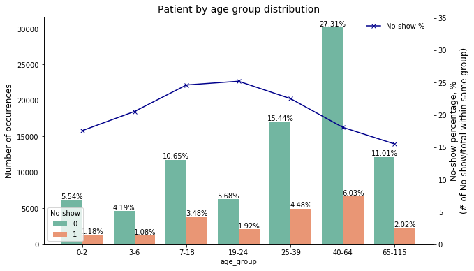

```python
# Visualise through plot
count_pct_plot(df, "age_group", "No-show", "No-show",
               "Patient by age group distribution", pct_age)
```

#### 3.3.2 Gender

- Majority of patient is **female**, ~ 65%.
- `No-show` percentage among male and female is about the same, ~ 20%

```python
pct = get_pct(df,"Gender")
```

```
Percentage groupby Gender
F    64.997602
M    35.002398
Name: Gender, dtype: float64

No-show percentage groupby:
Gender
F        20.311543
M        19.963810
Total    20.189828
dtype: float64
```

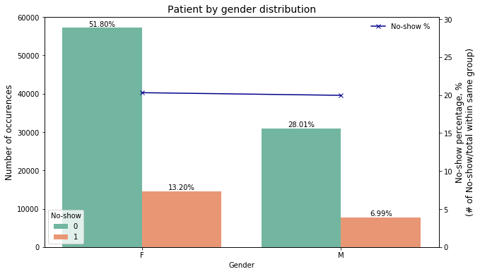

```python
# Visualise through plot
count_pct_plot(df, "Gender", "No-show", "No-show",
               "Patient by gender distribution", pct)
```

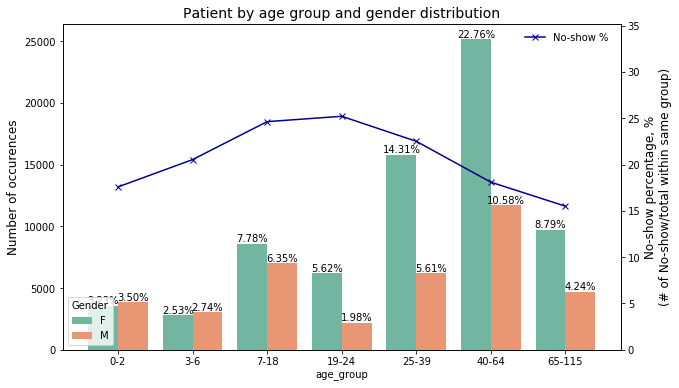

```python
# Combine both age group and gender, visualise thorugh plot
# Overall, majority of patient is from female for most of the age-group except patient below 7 years old.
count_pct_plot(df, "age_group", "Gender", "Gender",
               "Patient by age group and gender distribution", pct_age)
```

#### 3.3.3 Scholarship

- Majority patient is **not enrolled** in the scholoarship (~ 90.2%)
- Percentage of `No-show` for patient with scholarship is **higher** 23.7% (without : 19.8%)

```python
pct = get_pct(df,"Scholarship")
```

```
Percentage groupby Scholarship
0    90.172908
1     9.827092
Name: Scholarship, dtype: float64

No-show percentage groupby:
Scholarship
0        19.803331
1        23.736304
Total    20.189828
dtype: float64
```

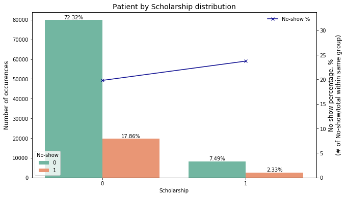

```python
# Visualise through plot
count_pct_plot(df, "Scholarship", "No-show", "No-show",
               "Patient by Scholarship distribution", pct)
```

#### 3.3.4 Hipertension

- Majority patient is **not having hipertension** (~ 80.3%)
- Percentage of `No-show` for patient with hipertension is **lower** 17.3% (without : 20.9%).

```python
pct = get_pct(df,"Hipertension")
```

```
Percentage groupby Hipertension
0    80.274337
1    19.725663
Name: Hipertension, dtype: float64

No-show percentage groupby:
Hipertension
0        20.899459
1        17.301959
Total    20.189828
dtype: float64
```

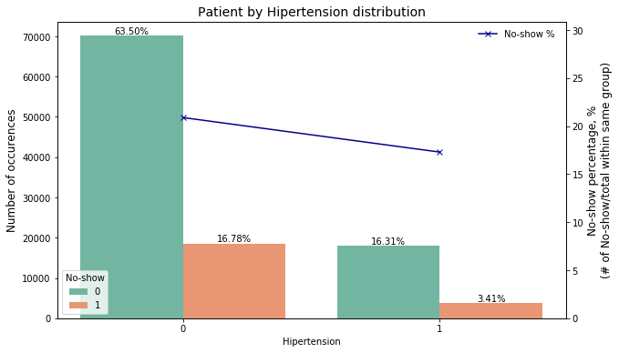

```python
# Visualise through plot
count_pct_plot(df, "Hipertension", "No-show", "No-show",
               "Patient by Hipertension distribution", pct)
```

#### 3.3.5 Diabetes

- Majority patient is **not having diabetes** (~ 92.8%)
- Percentage of `No-show` for patient with diabetes is **lower** 18% (without : 20.4%)

```python
pct_diabetes = get_pct(df,"Diabetes")
```

```
Percentage groupby Diabetes
0    92.813131
1     7.186869
Name: Diabetes, dtype: float64

No-show percentage groupby:
Diabetes
0        20.359141
1        18.003273
Total    20.189828
dtype: float64
```

[figure not shown]

```python
# Visualise through plot
count_pct_plot(df, "Diabetes", "No-show", "No-show",
               "Patient by Diabetes distribution", pct)
```

#### 3.3.6 Alcoholism

- Majority patient is **not having Alcoholism** (~ 97%)
- Percentage of `No-show` for patient with and without Alcoholism is about the same, ~ 20%

```python
pct = get_pct(df,"Alcoholism")
```

```
Percentage groupby Alcoholism
0    96.959854
1     3.040146
Name: Alcoholism, dtype: float64

No-show percentage groupby:
Alcoholism
0        20.191114
1        20.148810
Total    20.189828
dtype: float64
```

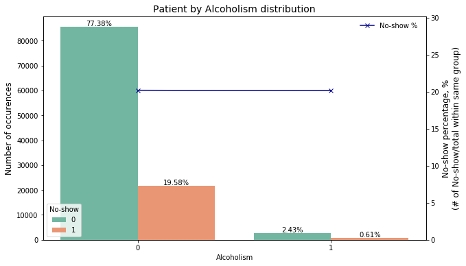

```python
# Visualise through plot
count_pct_plot(df, "Alcoholism", "No-show", "No-show",
               "Patient by Alcoholism distribution", pct)
```

#### 3.3.6 Handcap

- Majority patient is **not having disabilities** (~ 98%)
- Percentage of `No-show` for patient with severe disabilities is **higher** 33.3% for hancap =4

```python
pct = get_pct(df,"Handcap")
```

```
Percentage groupby Handcap
0    97.974141
1     1.845803
2     0.165579
3     0.011762
4     0.002714
Name: Handcap, dtype: float64

No-show percentage groupby:
Handcap
0        20.233280
1        17.843137
2        20.218579
3        23.076923
4        33.333333
Total    20.189828
dtype: float64
```

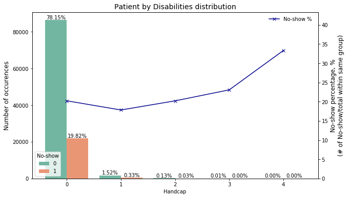

```python
# Visualise through plot
count_pct_plot(df, "Handcap", "No-show", "No-show",
               "Patient by Disabilities distribution", pct)
```

#### 3.3.7 Correlation among patient profiles and `No-show`

- Positive correlation between `Hipertension` and `Age` (0.5). Older patient has higher percentage of having Hipertension as well.
- Positive correlation between `Hipertension` and `Diabetes` (0.43). Patient with diabetes tend to have higher percentage of having Hipertension as well.
- These 2 groups of patient (Hipertension, Diabetes) have weak negative correlation with `No-show`. However, it was observed from the bar plot that, % of Hipertension of older patient increase, but the `No-show` rate is relatively lower.

```python
cols = ["Age", "Gender", "Scholarship", "Hipertension", "Diabetes", "Alcoholism", "SMS_received", "No-show"]
corr = df[cols].corr()
```

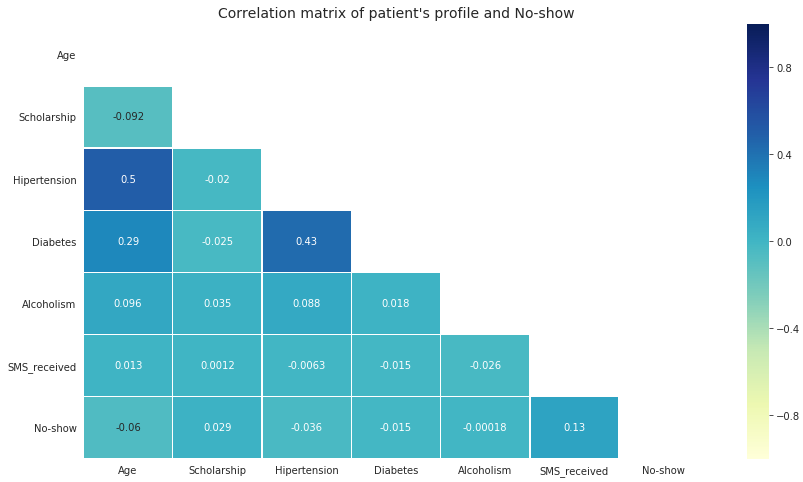

```python
# Visualise through heatmap
plot_heatmap(corr, (14,8), "Correlation matrix of patient's profile and No-show")
```

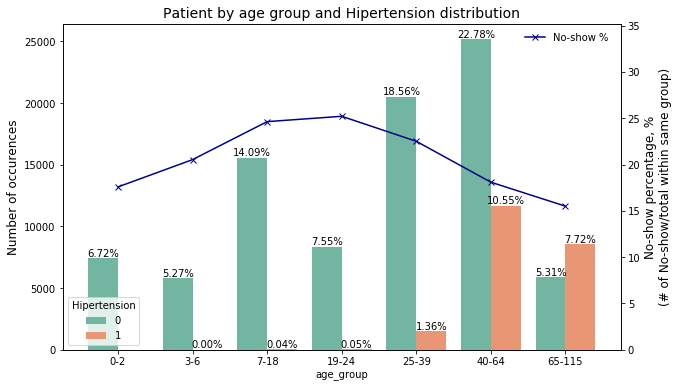

```python
# Combine both age group and Hipertension, visualise thorugh plot
count_pct_plot(df, "age_group", "Hipertension", "Hipertension",
               "Patient by age group and Hipertension distribution", pct_age)
```

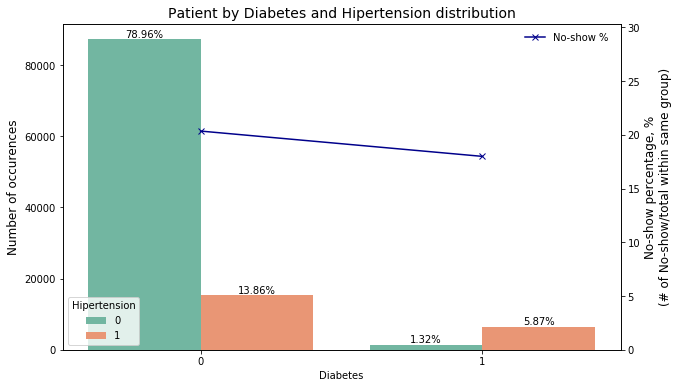

```python
# Combine both Diabetes and Hipertension, visualise thorugh plot
count_pct_plot(df, "Diabetes", "Hipertension", "Hipertension",
               "Patient by Diabetes and Hipertension distribution", pct_diabetes)
```

### 3.4 Any health unit (neighborhood) having higher No-show rate?

#### 3.4.1 Appointment by neighbourhood distribution

To find out the total number of appointment made by patient for each health unit and their corresponding `No-show` rate (percentage).

The analysis and visualisation observed that:

- There are total of **81** health units for the total of **110521** scheduled appointments. However, the number of scheduled appointment varied from the heatlth unit, with as low as 1 up to 7717.
- The average `No-show` percentage is **20.8%**.
- **ILHA DO BOI** is with lowest `No-show` rate of **8.6%** (3/35), whereas **ILHAS OCEÂNICAS DE TRINDADE** has the highest `No-show` rate of **100%** (2/2). But, these two health units are relatively with much lower scheduled appointment.
- **JARDIM CAMBURI** is the health unit with largest number of scheduled appointment and its' `No-show` percentage is **19%**, ~ 1% point lower than the average `No-show` percentage.
- **75 percentile** of the `No-show` is from 8.6% up to **21.8%**, thus the average of 20.8% is skewed by the **"outlier"** of one health unit of having 100% `No-show` rate.

```python
# create another dataframe to count the number of appointment made by each health unit (Neighbourhood)
nh_group = df.groupby(['Neighbourhood','No-show']).size().reset_index(name='count')
```

```python
# count the sum of appointment by each neighborhood
total = nh_group.groupby('Neighbourhood')['count'].sum()

# create another dataframe that merge the nh_group & total, to get the total column
nh_grouptotal = nh_group[nh_group['No-show'] == 1].merge(total, how='inner', on = 'Neighbourhood')
nh_grouptotal.rename(columns = {"count_x": "No-show_count", "count_y": "Total_count"}, inplace = True)
nh_grouptotal.drop('No-show', axis=1, inplace = True)

# count the percentage of No-show for each neighborhood
nh_grouptotal["No-show_pct"] = nh_grouptotal['No-show_count']/nh_grouptotal['Total_count']

# sort by neighborhood by number of patient (total_count)
nh_grouptotal.sort_values(by='Total_count',inplace=True)
nh_grouptotal.reset_index(drop=True, inplace=True)
nh_grouptotal.head()
```

|  | Neighbourhood | No-show_count | Total_count | No-show_pct |
| --- | --- | --- | --- | --- |
| 0 | ILHAS OCEÂNICAS DE TRINDADE | 2 | 2 | 1.000000 |
| 1 | AEROPORTO | 1 | 8 | 0.125000 |
| 2 | ILHA DO FRADE | 2 | 10 | 0.200000 |
| 3 | ILHA DO BOI | 3 | 35 | 0.085714 |
| 4 | PONTAL DE CAMBURI | 12 | 69 | 0.173913 |

```python
# Get the statistic description of the data.
# There are actually 81 unique Neighbourhood. The one missing here is 'PARQUE INDUSTRIAL', where it only has
# 1 appointment, where the patient is from 7-18 age-group
nh_grouptotal.describe()
```

|  | No-show_count | Total_count | No-show_pct |
| --- | --- | --- | --- |
| count | 80.000000 | 80.000000 | 80.000000 |
| mean | 278.925000 | 1381.500000 | 0.207975 |
| std | 277.942202 | 1369.086492 | 0.095045 |
| min | 1.000000 | 2.000000 | 0.085714 |
| 25% | 75.000000 | 420.500000 | 0.180461 |
| 50% | 184.500000 | 854.500000 | 0.197650 |
| 75% | 428.250000 | 2067.000000 | 0.217709 |
| max | 1465.000000 | 7717.000000 | 1.000000 |

```python
# Health unit (neighborhood) with lowest No-show percentage:
nh_grouptotal.iloc[nh_grouptotal['No-show_pct'].idxmin()]
```

```
Neighbourhood    ILHA DO BOI
No-show_count              3
Total_count               35
No-show_pct        0.0857143
Name: 3, dtype: object
```

```python
# Health unit (neighborhood) with highest appointment/ patient:
# It also has the highest No-show count
nh_grouptotal.iloc[nh_grouptotal['Total_count'].idxmax()]
```

```
Neighbourhood    JARDIM CAMBURI
No-show_count              1465
Total_count                7717
No-show_pct            0.189841
Name: 79, dtype: object
```

**Visualisation** of Total number of appointments and `No-show` rates for each health unit (Neighbourhood)

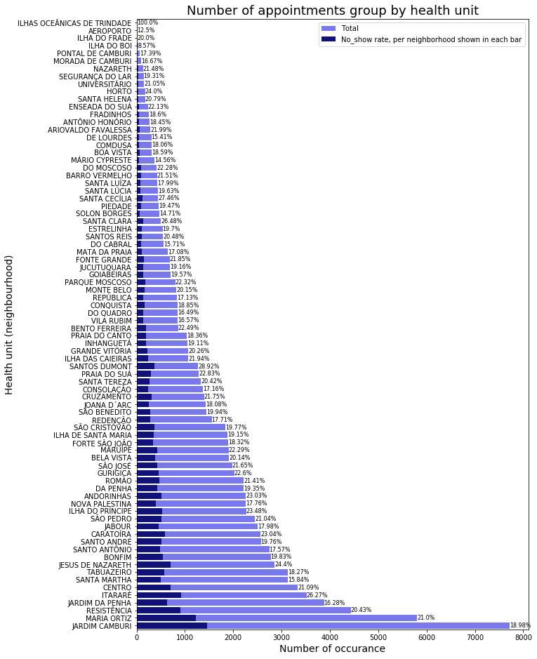

```python
#Visualise the total appointments and No-show rates for each Neighbourhood, using barplot
plt.subplots(figsize=(10,16))

ax = sns.barplot(x = "Total_count", y = "Neighbourhood", data = nh_grouptotal,
                label = 'Total', color ='blue', alpha=0.6)

# get the No_show perecentage data
no_show_pct = round(nh_grouptotal['No-show_pct']*100, 2)

# loop through the ax to lable the No-show percentage for each neighbourhood
for idx, i in enumerate(ax.patches):
    ax.text(i.get_width()+.01, i.get_y()+.65, str(no_show_pct[idx])+"%", fontsize=8)

ax = sns.barplot(x="No-show_count", y = "Neighbourhood", data = nh_grouptotal,
                label = "No_show rate, per neighborhood shown in each bar", color = 'darkblue')

ax.legend()
ax.set_xlabel("Number of occurance", fontsize=14)
ax.set_ylabel("Health unit (neighbourhood)", fontsize=14)
ax.set_title("Number of appointments group by health unit", fontsize=18);
```

#### 3.4.2 Appointment by Neighbourhood and by patient's age group distribution

This section is to find out, for each health unit (Neighbourhood), what is the `No-show` rate for each age group of patient.  
The visualisation plot in later code-cell shows the health unit from the least (top in the plot) down to the max number of scheduled appointments made by patient.  
`Overall No-show` is the `No-show` percentage per health unit (that is the same data shown in the bar chart in 3.4.1). It follows by the `No-show` rate for each age group within the health unit. (e.g., there are total of 10 scheduled appointment from 0-2 age-group and 2 of them is No-show, thus the No-show rate for this age-group is 20%).

```python
# Get the number of appointment, break-down by Neighbourhood, age group and No-show status
nh_age = df.groupby(["Neighbourhood", "age_group", "No-show"]).size()
nh_age = nh_age.unstack(-1).unstack(-1)
nh_age
```

| No-show age_group Neighbourhood | 0 0-2 | 0 3-6 | 0 7-18 | 0 19-24 | 0 25-39 | 0 40-64 | 0 65-115 | 1 0-2 | 1 3-6 | 1 7-18 | 1 19-24 | 1 25-39 | 1 40-64 | 1 65-115 |
| --- | --- | --- | --- | --- | --- | --- | --- | --- | --- | --- | --- | --- | --- | --- |
| AEROPORTO | 0 | 0 | 0 | 0 | 1 | 6 | 0 | 0 | 0 | 0 | 0 | 1 | 0 | 0 |
| ANDORINHAS | 105 | 82 | 265 | 147 | 375 | 547 | 220 | 28 | 23 | 91 | 31 | 144 | 154 | 50 |
| ANTÔNIO HONÓRIO | 16 | 6 | 27 | 15 | 42 | 85 | 30 | 5 | 4 | 12 | 8 | 11 | 7 | 3 |
| ARIOVALDO FAVALESSA | 21 | 13 | 44 | 22 | 33 | 65 | 22 | 2 | 3 | 15 | 8 | 13 | 13 | 8 |
| BARRO VERMELHO | 11 | 6 | 21 | 18 | 71 | 151 | 54 | 2 | 3 | 7 | 9 | 20 | 43 | 7 |
| ... | ... | ... | ... | ... | ... | ... | ... | ... | ... | ... | ... | ... | ... | ... |
| SÃO JOSÉ | 160 | 92 | 239 | 112 | 337 | 424 | 185 | 52 | 20 | 81 | 38 | 74 | 115 | 48 |
| SÃO PEDRO | 168 | 95 | 276 | 93 | 409 | 623 | 269 | 42 | 18 | 83 | 30 | 139 | 151 | 52 |
| TABUAZEIRO | 187 | 199 | 373 | 202 | 446 | 835 | 317 | 30 | 45 | 125 | 51 | 116 | 157 | 48 |
| UNIVERSITÁRIO | 3 | 4 | 10 | 5 | 36 | 42 | 20 | 1 | 1 | 2 | 0 | 12 | 16 | 0 |
| VILA RUBIM | 37 | 9 | 52 | 44 | 108 | 308 | 152 | 7 | 7 | 16 | 15 | 35 | 43 | 18 |

81 rows × 14 columns

```python
# Create another dataframe to calculate the No-show percentage for each neighbourhood break-down by age group

nh_age_noshowpct = nh_age.loc[:,1]/(nh_age.loc[:,0]+nh_age.loc[:,1])
nh_age_noshowpct.fillna(0, inplace=True)  # fill NaN to 0
nh_age_noshowpct.head()
```

| age_group Neighbourhood | 0-2 | 3-6 | 7-18 | 19-24 | 25-39 | 40-64 | 65-115 |
| --- | --- | --- | --- | --- | --- | --- | --- |
| AEROPORTO | 0.000000 | 0.000000 | 0.000000 | 0.000000 | 0.500000 | 0.000000 | 0.000000 |
| ANDORINHAS | 0.210526 | 0.219048 | 0.255618 | 0.174157 | 0.277457 | 0.219686 | 0.185185 |
| ANTÔNIO HONÓRIO | 0.238095 | 0.400000 | 0.307692 | 0.347826 | 0.207547 | 0.076087 | 0.090909 |
| ARIOVALDO FAVALESSA | 0.086957 | 0.187500 | 0.254237 | 0.266667 | 0.282609 | 0.166667 | 0.266667 |
| BARRO VERMELHO | 0.153846 | 0.333333 | 0.250000 | 0.333333 | 0.219780 | 0.221649 | 0.114754 |

```python
# Remove the multi-index
nh_age_noshowpct.columns = nh_age_noshowpct.columns.astype('str')
nh_age_noshowpct.reset_index(inplace =True)
nh_age_noshowpct.head()
```

| age_group | Neighbourhood | 0-2 | 3-6 | 7-18 | 19-24 | 25-39 | 40-64 | 65-115 |
| --- | --- | --- | --- | --- | --- | --- | --- | --- |
| 0 | AEROPORTO | 0.000000 | 0.000000 | 0.000000 | 0.000000 | 0.500000 | 0.000000 | 0.000000 |
| 1 | ANDORINHAS | 0.210526 | 0.219048 | 0.255618 | 0.174157 | 0.277457 | 0.219686 | 0.185185 |
| 2 | ANTÔNIO HONÓRIO | 0.238095 | 0.400000 | 0.307692 | 0.347826 | 0.207547 | 0.076087 | 0.090909 |
| 3 | ARIOVALDO FAVALESSA | 0.086957 | 0.187500 | 0.254237 | 0.266667 | 0.282609 | 0.166667 | 0.266667 |
| 4 | BARRO VERMELHO | 0.153846 | 0.333333 | 0.250000 | 0.333333 | 0.219780 | 0.221649 | 0.114754 |

```python
# Merge it with nh_grouptotal dataframe that created earlier
nh_combined = nh_grouptotal.merge(nh_age_noshowpct, how="inner", on = "Neighbourhood")
nh_combined.drop(['No-show_count', 'Total_count'], axis=1, inplace=True)
nh_combined.set_index('Neighbourhood', inplace=True)
nh_combined.rename(columns = {"No-show_pct": "Overall No-show"}, inplace=True)
nh_combined.head()
```

| Neighbourhood | Overall No-show | 0-2 | 3-6 | 7-18 | 19-24 | 25-39 | 40-64 | 65-115 |
| --- | --- | --- | --- | --- | --- | --- | --- | --- |
| ILHAS OCEÂNICAS DE TRINDADE | 1.000000 | 0.0 | 0.0 | 0.00 | 0.000000 | 0.000000 | 1.000000 | 0.00 |
| AEROPORTO | 0.125000 | 0.0 | 0.0 | 0.00 | 0.000000 | 0.500000 | 0.000000 | 0.00 |
| ILHA DO FRADE | 0.200000 | 0.0 | 0.0 | 0.00 | 0.000000 | 0.250000 | 0.000000 | 0.00 |
| ILHA DO BOI | 0.085714 | 0.0 | 0.0 | 0.00 | 0.200000 | 0.100000 | 0.090909 | 0.00 |
| PONTAL DE CAMBURI | 0.173913 | 0.5 | 0.0 | 0.25 | 0.333333 | 0.117647 | 0.095238 | 0.25 |

```python
# Statistical description of No-show rate (overall and per age-group)
# 3-6, 7-18, 29-14, 25-39 in general has higher mean No-show rate (>20%)
# senior (65-115) has the lowest mean No-show rate (14.1%)
nh_combined.describe()
```

|  | Overall No-show | 0-2 | 3-6 | 7-18 | 19-24 | 25-39 | 40-64 | 65-115 |
| --- | --- | --- | --- | --- | --- | --- | --- | --- |
| count | 80.000000 | 80.000000 | 80.000000 | 80.000000 | 80.000000 | 80.000000 | 80.000000 | 80.000000 |
| mean | 0.207975 | 0.185588 | 0.222799 | 0.231419 | 0.243521 | 0.218256 | 0.184329 | 0.140929 |
| std | 0.095045 | 0.103776 | 0.142015 | 0.082393 | 0.111737 | 0.062033 | 0.104871 | 0.062772 |
| min | 0.085714 | 0.000000 | 0.000000 | 0.000000 | 0.000000 | 0.000000 | 0.000000 | 0.000000 |
| 25% | 0.180461 | 0.127544 | 0.152665 | 0.199603 | 0.196830 | 0.187194 | 0.147159 | 0.111148 |
| 50% | 0.197650 | 0.176471 | 0.192154 | 0.237750 | 0.248533 | 0.221311 | 0.174802 | 0.146471 |
| 75% | 0.217709 | 0.228816 | 0.280093 | 0.271107 | 0.295490 | 0.254340 | 0.203688 | 0.177047 |
| max | 1.000000 | 0.588235 | 1.000000 | 0.478261 | 0.636364 | 0.500000 | 1.000000 | 0.266667 |

**Visualisation** of the Overall `No-show` percentage for each health unit (Neighbourhood) and the `No-show` rate from each age-group

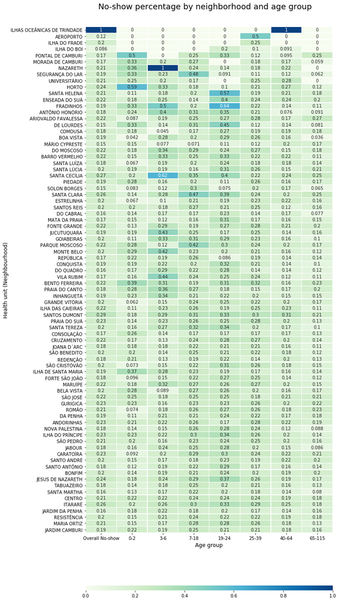

```python
# Visualisation through heatmap
fig, ax = plt.subplots(figsize=(10, 25))
fig.subplots_adjust(top=.95)
plt.suptitle('No-show percentage by neighborhood and age group', fontsize=18)
cbar_kws = {'orientation':"horizontal", 'pad':0.08, 'aspect':50}

ax = sns.heatmap(nh_combined, annot=True, linewidths=.3, cmap='GnBu', cbar_kws=cbar_kws);
ax.set_xlabel("Age group", fontsize=12);
ax.set_ylabel("Health unit (Neighbourhood)", fontsize=12);
```

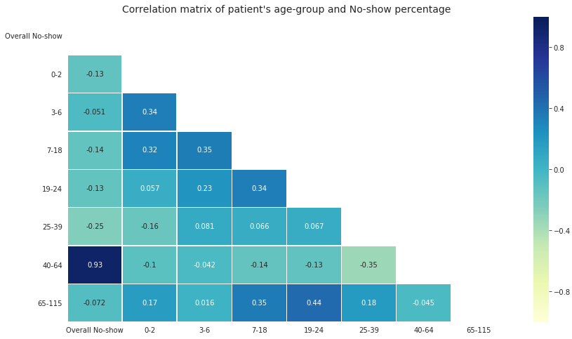

```python
# calculate the correlation matrix of No-show rate per age-group, and the Overall No-show percentage
# The overall No-show percentage has strong positive correlation with No-show rate of 40-64 age-group.
corr = nh_combined.corr()
# Visualise through heatmap
plot_heatmap(corr, (14,8), "Correlation matrix of patient's age-group and No-show percentage")
```

## 4 Conclusions

> This project is to analyse the medical appointments data in Brazil and focus to explore insights on the possible factors that contribute to patient that did not showed up on their scheduled appointment. It does not include statistical tests, model prediction or causal relations.

> **No-show percentage**
> - Overall, the dataset is only for scheduled appointment in *2 month* (Apr-June 2016).
> - **20.2%** of the patient **not showed up** in their scheduled appointment.

**No-show appointment**

- Scheduling and appointment only made from *Monday - Saturday*. Least appointment scheduled on **Saturday**, but it has **highest** `No-show` rate (i.e. number of No-show/ number of showed up on Saturday).
- Majority scheduling is made on the **same day** (39.6%), with `No-show` rate the least on it as well (6.6%). The `No-show` rate **increases with increasing waiting time** and peak at waiting time after a month (i.e. in group 31-90 days).

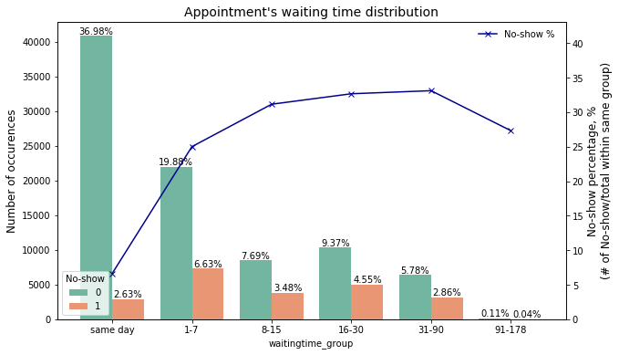

```python
# replot the graph here again
count_pct_plot(df, "waitingtime_group", "No-show", "No-show",
               "Appointment's waiting time distribution", pct_waitingtime)
```

- It was also observed that the `No-show` patient is less frequent patient (appointment made per patient < 20). In addition, frequent patient (> 20 appointment per patient) mostly scheduled appointment on the **same** day.
- Only 32.1% patient received **sms** notification and no notification send out for appointment made on the same day. More patient received sms notification if they have longer waiting time, but the `No-show` rate remain higher for longer waiting time.

**Patient profile**

- Though female make up the majority group of patient (65%), but the `No-show` rate is ~20% for both gender.
- Majority patient is without medical condition (`Hipertension`, `Diabetes`,`Alcoholism`), but with **higher** `NO-show` rate compared to the patient with medical condition.
- Vast majority patient is without disabilities(97%). Among the handicap group, higher `No-show` rate observed from patient with more severe disabilities (handcap = 3, 4).
- Majority patient is not enrolled in the scholorship program, but those **enrolled has higher `No-show` rate**.
- Majority patient is from **middle age group** (40-64 years old, ~ 33.3%). But, patient with highest `No-show` rate is from **19-24** age group (25.2%).

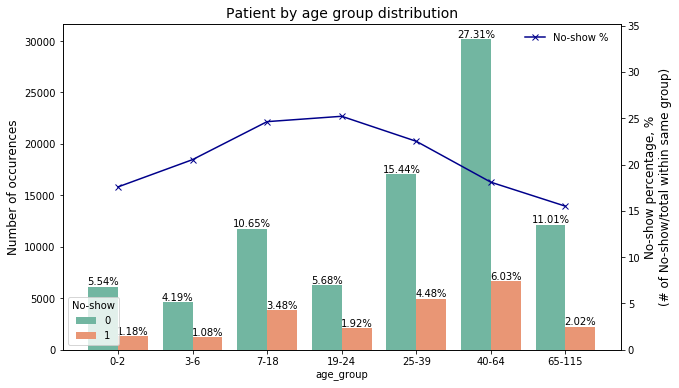

```python
# Replot the graph
count_pct_plot(df, "age_group", "No-show", "No-show",
               "Patient by age group distribution", pct_age)
```

**Analysis limitations:**

- The data is only consist of appointment within 2 months timespan, which might not be representing the overall picture of the No-show situation.
- There is missing details in the time of appointment, it only consist the date, which could give valuable insights.
- No details on the category of appointment made, for example general GP consultation, medical condition follow-up, medical check-up & etc, which might help in gaining more insights.